# Risk Factor Analysis

## Outcome Variable

**Outcome Variable:** stunted

## Predictor Variables

**Intervention Variable:** nchldlt5

**Adjustment Set:**

- arm
- W_mage
- meducyrs
- feducyrs
- hhwealth_quart
- hfoodsec
- W_mhtcm
- W_nrooms
- W_parity
- impfloor
- impsan
- safeh20
- delta_W_mage
- delta_meducyrs
- delta_feducyrs
- delta_hhwealth_quart
- delta_hfoodsec
- delta_W_mhtcm
- delta_W_nrooms
- delta_W_parity
- delta_impfloor
- delta_impsan
- delta_safeh20

## Stratifying Variables

The analysis was stratified on these variable(s):

- agecat
- studyid
- country

## Data Summary

| agecat | studyid | country | nchldlt5 | stunted | n_cell | n |
| --- | --- | --- | --- | --- | --- | --- |
| 6 months | ki1000108-IRC | INDIA | 1 | 0 | 67 | 407 |
| 6 months | ki1000108-IRC | INDIA | 1 | 1 | 22 | 407 |
| 6 months | ki1000108-IRC | INDIA | 2 | 0 | 90 | 407 |
| 6 months | ki1000108-IRC | INDIA | 2 | 1 | 29 | 407 |
| 6 months | ki1000108-IRC | INDIA | 3+ | 0 | 150 | 407 |
| 6 months | ki1000108-IRC | INDIA | 3+ | 1 | 49 | 407 |
| 24 months | ki1000108-IRC | INDIA | 1 | 0 | 58 | 409 |
| 24 months | ki1000108-IRC | INDIA | 1 | 1 | 31 | 409 |
| 24 months | ki1000108-IRC | INDIA | 2 | 0 | 73 | 409 |
| 24 months | ki1000108-IRC | INDIA | 2 | 1 | 46 | 409 |
| 24 months | ki1000108-IRC | INDIA | 3+ | 0 | 108 | 409 |
| 24 months | ki1000108-IRC | INDIA | 3+ | 1 | 93 | 409 |
| Birth | ki1000108-IRC | INDIA | 1 | 0 | 72 | 388 |
| Birth | ki1000108-IRC | INDIA | 1 | 1 | 12 | 388 |
| Birth | ki1000108-IRC | INDIA | 2 | 0 | 100 | 388 |
| Birth | ki1000108-IRC | INDIA | 2 | 1 | 14 | 388 |
| Birth | ki1000108-IRC | INDIA | 3+ | 0 | 171 | 388 |
| Birth | ki1000108-IRC | INDIA | 3+ | 1 | 19 | 388 |
| 6 months | ki1017093b-PROVIDE | BANGLADESH | 1 | 0 | 357 | 583 |
| 6 months | ki1017093b-PROVIDE | BANGLADESH | 1 | 1 | 69 | 583 |
| 6 months | ki1017093b-PROVIDE | BANGLADESH | 2 | 0 | 124 | 583 |
| 6 months | ki1017093b-PROVIDE | BANGLADESH | 2 | 1 | 24 | 583 |
| 6 months | ki1017093b-PROVIDE | BANGLADESH | 3+ | 0 | 8 | 583 |
| 6 months | ki1017093b-PROVIDE | BANGLADESH | 3+ | 1 | 1 | 583 |
| 24 months | ki1017093b-PROVIDE | BANGLADESH | 1 | 0 | 298 | 577 |
| 24 months | ki1017093b-PROVIDE | BANGLADESH | 1 | 1 | 125 | 577 |
| 24 months | ki1017093b-PROVIDE | BANGLADESH | 2 | 0 | 83 | 577 |
| 24 months | ki1017093b-PROVIDE | BANGLADESH | 2 | 1 | 63 | 577 |
| 24 months | ki1017093b-PROVIDE | BANGLADESH | 3+ | 0 | 6 | 577 |
| 24 months | ki1017093b-PROVIDE | BANGLADESH | 3+ | 1 | 2 | 577 |

[output cut: 58 more lines]

The following strata were considered:

- agecat: 24 months, studyid: ki1000108-IRC, country: INDIA
- agecat: 24 months, studyid: ki1017093b-PROVIDE, country: BANGLADESH
- agecat: 24 months, studyid: ki1017093c-NIH-Crypto, country: BANGLADESH
- agecat: 24 months, studyid: ki1066203-TanzaniaChild2, country: TANZANIA, UNITED REPUBLIC OF
- agecat: 24 months, studyid: ki1148112-LCNI-5, country: MALAWI
- agecat: 24 months, studyid: kiGH5241-JiVitA-3, country: BANGLADESH
- agecat: 6 months, studyid: ki1000108-IRC, country: INDIA
- agecat: 6 months, studyid: ki1017093b-PROVIDE, country: BANGLADESH
- agecat: 6 months, studyid: ki1017093c-NIH-Crypto, country: BANGLADESH
- agecat: 6 months, studyid: ki1066203-TanzaniaChild2, country: TANZANIA, UNITED REPUBLIC OF
- agecat: 6 months, studyid: ki1148112-LCNI-5, country: MALAWI
- agecat: 6 months, studyid: kiGH5241-JiVitA-3, country: BANGLADESH
- agecat: Birth, studyid: ki1000108-IRC, country: INDIA
- agecat: Birth, studyid: ki1017093c-NIH-Crypto, country: BANGLADESH
- agecat: Birth, studyid: kiGH5241-JiVitA-3, country: BANGLADESH

### Dropped Strata

Some strata were dropped due to rare outcomes:

- agecat: 6 months, studyid: ki1017093b-PROVIDE, country: BANGLADESH
- agecat: 24 months, studyid: ki1017093b-PROVIDE, country: BANGLADESH
- agecat: Birth, studyid: ki1017093c-NIH-Crypto, country: BANGLADESH
- agecat: 6 months, studyid: ki1017093c-NIH-Crypto, country: BANGLADESH
- agecat: 24 months, studyid: ki1017093c-NIH-Crypto, country: BANGLADESH
- agecat: 24 months, studyid: ki1066203-TanzaniaChild2, country: TANZANIA, UNITED REPUBLIC OF

## Methods Detail

We’re interested in the causal parameters $E[Y_a]$ for all values of $a \in \mathcal{A}$. These parameters represent the mean outcome if, possibly contrary to fact, we intervened to set all units to have $A=a$. Under the randomization and positivity assumptions, these are identified by the statistical parameters $\psi_a=E_W[E_{Y|A,W}(Y|A=a,W)]$. In addition, we’re interested in the mean of $Y$, $E[Y]$ under no intervention (the observed mean). We will estimate these parameters by using SuperLearner to fit the relevant likelihood factors – $E_{Y|A,W}(Y|A=a,W)$ and $p(A=a|W)$, and then updating our likelihood fit using a joint TMLE.

For unadjusted analyses ($W=\{\}$), initial likelihoods were estimated using Lrnr_glm to estimate the simple $E(Y|A)$ and Lrnr_mean to estimate $p(A)$. For adjusted analyses, a small library containing Lrnr_glmnet, Lrnr_xgboost, and Lrnr_mean was used.

Having estimated these parameters, we will then use the delta method to estimate relative risks and attributable risks relative to a prespecified baseline level of $A$.

# Results Detail

## Results Plots

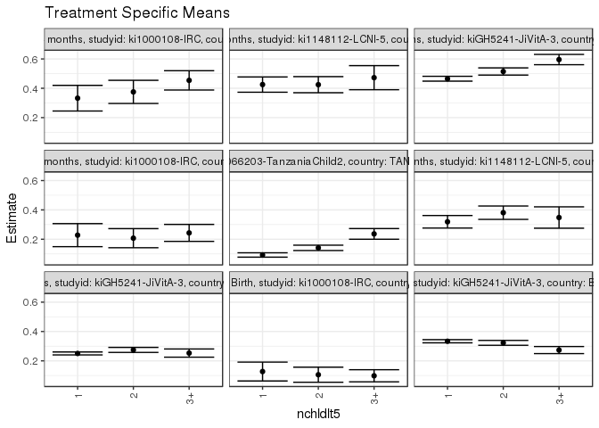

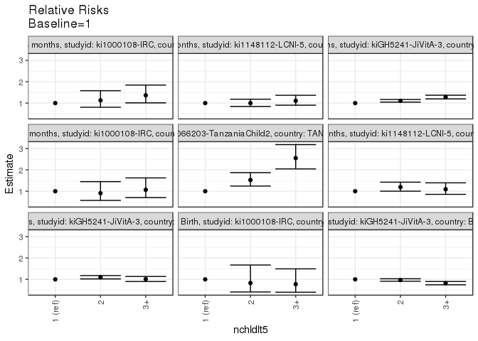

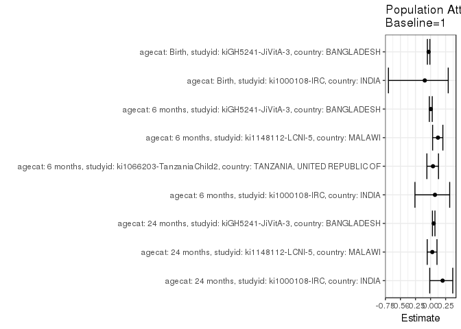

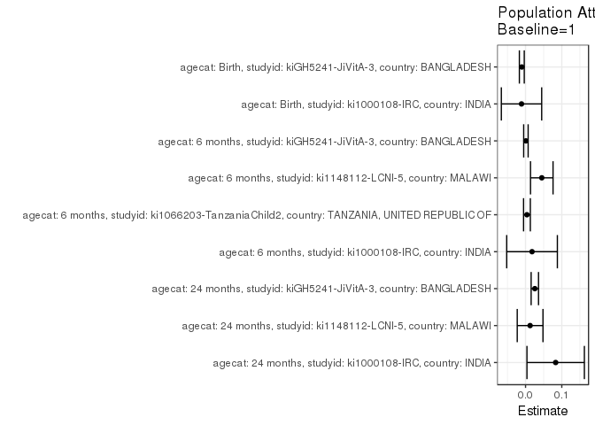

## Results Table

### Parameter: TSM

| agecat | studyid | country | intervention_level | baseline_level | estimate | ci_lower | ci_upper |
| --- | --- | --- | --- | --- | --- | --- | --- |
| Birth | ki1000108-IRC | INDIA | 1 | NA | 0.1270962 | 0.0627593 | 0.1914331 |
| Birth | ki1000108-IRC | INDIA | 2 | NA | 0.1053088 | 0.0538958 | 0.1567218 |
| Birth | ki1000108-IRC | INDIA | 3+ | NA | 0.0981568 | 0.0567491 | 0.1395645 |
| Birth | kiGH5241-JiVitA-3 | BANGLADESH | 1 | NA | 0.3335663 | 0.3228234 | 0.3443091 |
| Birth | kiGH5241-JiVitA-3 | BANGLADESH | 2 | NA | 0.3227150 | 0.3060501 | 0.3393799 |
| Birth | kiGH5241-JiVitA-3 | BANGLADESH | 3+ | NA | 0.2734372 | 0.2494363 | 0.2974381 |
| 6 months | ki1000108-IRC | INDIA | 1 | NA | 0.2277955 | 0.1492364 | 0.3063545 |
| 6 months | ki1000108-IRC | INDIA | 2 | NA | 0.2071574 | 0.1419566 | 0.2723583 |
| 6 months | ki1000108-IRC | INDIA | 3+ | NA | 0.2431780 | 0.1852699 | 0.3010861 |
| 6 months | ki1066203-TanzaniaChild2 | TANZANIA, UNITED REPUBLIC OF | 1 | NA | 0.0926651 | 0.0777694 | 0.1075608 |
| 6 months | ki1066203-TanzaniaChild2 | TANZANIA, UNITED REPUBLIC OF | 2 | NA | 0.1412082 | 0.1228823 | 0.1595342 |
| 6 months | ki1066203-TanzaniaChild2 | TANZANIA, UNITED REPUBLIC OF | 3+ | NA | 0.2363670 | 0.1999990 | 0.2727350 |
| 6 months | ki1148112-LCNI-5 | MALAWI | 1 | NA | 0.3189516 | 0.2762814 | 0.3616219 |
| 6 months | ki1148112-LCNI-5 | MALAWI | 2 | NA | 0.3809051 | 0.3351893 | 0.4266210 |
| 6 months | ki1148112-LCNI-5 | MALAWI | 3+ | NA | 0.3479373 | 0.2751821 | 0.4206924 |
| 6 months | kiGH5241-JiVitA-3 | BANGLADESH | 1 | NA | 0.2503546 | 0.2402854 | 0.2604239 |
| 6 months | kiGH5241-JiVitA-3 | BANGLADESH | 2 | NA | 0.2744813 | 0.2573148 | 0.2916478 |
| 6 months | kiGH5241-JiVitA-3 | BANGLADESH | 3+ | NA | 0.2530175 | 0.2250933 | 0.2809416 |
| 24 months | ki1000108-IRC | INDIA | 1 | NA | 0.3325499 | 0.2451477 | 0.4199521 |
| 24 months | ki1000108-IRC | INDIA | 2 | NA | 0.3753997 | 0.2964266 | 0.4543728 |
| 24 months | ki1000108-IRC | INDIA | 3+ | NA | 0.4538826 | 0.3881315 | 0.5196337 |
| 24 months | ki1148112-LCNI-5 | MALAWI | 1 | NA | 0.4252494 | 0.3731823 | 0.4773166 |
| 24 months | ki1148112-LCNI-5 | MALAWI | 2 | NA | 0.4245620 | 0.3696382 | 0.4794858 |
| 24 months | ki1148112-LCNI-5 | MALAWI | 3+ | NA | 0.4723044 | 0.3901312 | 0.5544776 |
| 24 months | kiGH5241-JiVitA-3 | BANGLADESH | 1 | NA | 0.4651010 | 0.4486346 | 0.4815675 |
| 24 months | kiGH5241-JiVitA-3 | BANGLADESH | 2 | NA | 0.5145228 | 0.4899941 | 0.5390514 |
| 24 months | kiGH5241-JiVitA-3 | BANGLADESH | 3+ | NA | 0.5957123 | 0.5607138 | 0.6307107 |

### Parameter: E(Y)

| agecat | studyid | country | intervention_level | baseline_level | estimate | ci_lower | ci_upper |
| --- | --- | --- | --- | --- | --- | --- | --- |
| Birth | ki1000108-IRC | INDIA | NA | NA | 0.1159794 | 0.0840777 | 0.1478811 |
| Birth | kiGH5241-JiVitA-3 | BANGLADESH | NA | NA | 0.3232607 | 0.3156042 | 0.3309171 |
| 6 months | ki1000108-IRC | INDIA | NA | NA | 0.2457002 | 0.2038248 | 0.2875757 |
| 6 months | ki1066203-TanzaniaChild2 | TANZANIA, UNITED REPUBLIC OF | NA | NA | 0.0965347 | 0.0836528 | 0.1094165 |
| 6 months | ki1148112-LCNI-5 | MALAWI | NA | NA | 0.3637485 | 0.3306185 | 0.3968784 |
| 6 months | kiGH5241-JiVitA-3 | BANGLADESH | NA | NA | 0.2513690 | 0.2432434 | 0.2594947 |
| 24 months | ki1000108-IRC | INDIA | NA | NA | 0.4156479 | 0.3678270 | 0.4634689 |
| 24 months | ki1148112-LCNI-5 | MALAWI | NA | NA | 0.4378284 | 0.3971000 | 0.4785567 |
| 24 months | kiGH5241-JiVitA-3 | BANGLADESH | NA | NA | 0.4907214 | 0.4775947 | 0.5038481 |

### Parameter: RR

| agecat | studyid | country | intervention_level | baseline_level | estimate | ci_lower | ci_upper |
| --- | --- | --- | --- | --- | --- | --- | --- |
| Birth | ki1000108-IRC | INDIA | 1 | 1 | 1.0000000 | 1.0000000 | 1.0000000 |
| Birth | ki1000108-IRC | INDIA | 2 | 1 | 0.8285757 | 0.4106706 | 1.6717478 |
| Birth | ki1000108-IRC | INDIA | 3+ | 1 | 0.7723033 | 0.3997984 | 1.4918830 |
| Birth | kiGH5241-JiVitA-3 | BANGLADESH | 1 | 1 | 1.0000000 | 1.0000000 | 1.0000000 |
| Birth | kiGH5241-JiVitA-3 | BANGLADESH | 2 | 1 | 0.9674689 | 0.9109686 | 1.0274734 |
| Birth | kiGH5241-JiVitA-3 | BANGLADESH | 3+ | 1 | 0.8197387 | 0.7462310 | 0.9004874 |
| 6 months | ki1000108-IRC | INDIA | 1 | 1 | 1.0000000 | 1.0000000 | 1.0000000 |
| 6 months | ki1000108-IRC | INDIA | 2 | 1 | 0.9094011 | 0.5705130 | 1.4495908 |
| 6 months | ki1000108-IRC | INDIA | 3+ | 1 | 1.0675278 | 0.7023049 | 1.6226795 |
| 6 months | ki1066203-TanzaniaChild2 | TANZANIA, UNITED REPUBLIC OF | 1 | 1 | 1.0000000 | 1.0000000 | 1.0000000 |
| 6 months | ki1066203-TanzaniaChild2 | TANZANIA, UNITED REPUBLIC OF | 2 | 1 | 1.5238555 | 1.2415726 | 1.8703180 |
| 6 months | ki1066203-TanzaniaChild2 | TANZANIA, UNITED REPUBLIC OF | 3+ | 1 | 2.5507664 | 2.0446134 | 3.1822199 |
| 6 months | ki1148112-LCNI-5 | MALAWI | 1 | 1 | 1.0000000 | 1.0000000 | 1.0000000 |
| 6 months | ki1148112-LCNI-5 | MALAWI | 2 | 1 | 1.1942410 | 1.0020496 | 1.4232944 |
| 6 months | ki1148112-LCNI-5 | MALAWI | 3+ | 1 | 1.0908779 | 0.8544474 | 1.3927299 |
| 6 months | kiGH5241-JiVitA-3 | BANGLADESH | 1 | 1 | 1.0000000 | 1.0000000 | 1.0000000 |
| 6 months | kiGH5241-JiVitA-3 | BANGLADESH | 2 | 1 | 1.0963698 | 1.0205453 | 1.1778278 |
| 6 months | kiGH5241-JiVitA-3 | BANGLADESH | 3+ | 1 | 1.0106363 | 0.9003513 | 1.1344302 |
| 24 months | ki1000108-IRC | INDIA | 1 | 1 | 1.0000000 | 1.0000000 | 1.0000000 |
| 24 months | ki1000108-IRC | INDIA | 2 | 1 | 1.1288521 | 0.8064555 | 1.5801334 |
| 24 months | ki1000108-IRC | INDIA | 3+ | 1 | 1.3648556 | 1.0109312 | 1.8426881 |
| 24 months | ki1148112-LCNI-5 | MALAWI | 1 | 1 | 1.0000000 | 1.0000000 | 1.0000000 |
| 24 months | ki1148112-LCNI-5 | MALAWI | 2 | 1 | 0.9983834 | 0.8424354 | 1.1831999 |
| 24 months | ki1148112-LCNI-5 | MALAWI | 3+ | 1 | 1.1106526 | 0.9025394 | 1.3667539 |
| 24 months | kiGH5241-JiVitA-3 | BANGLADESH | 1 | 1 | 1.0000000 | 1.0000000 | 1.0000000 |
| 24 months | kiGH5241-JiVitA-3 | BANGLADESH | 2 | 1 | 1.1062602 | 1.0464818 | 1.1694534 |
| 24 months | kiGH5241-JiVitA-3 | BANGLADESH | 3+ | 1 | 1.2808234 | 1.1972231 | 1.3702613 |

### Parameter: PAR

| agecat | studyid | country | intervention_level | baseline_level | estimate | ci_lower | ci_upper |
| --- | --- | --- | --- | --- | --- | --- | --- |
| Birth | ki1000108-IRC | INDIA | 1 | NA | -0.0111168 | -0.0667808 | 0.0445472 |
| Birth | kiGH5241-JiVitA-3 | BANGLADESH | 1 | NA | -0.0103056 | -0.0170368 | -0.0035744 |
| 6 months | ki1000108-IRC | INDIA | 1 | NA | 0.0179048 | -0.0519946 | 0.0878042 |
| 6 months | ki1066203-TanzaniaChild2 | TANZANIA, UNITED REPUBLIC OF | 1 | NA | 0.0038695 | -0.0054677 | 0.0132068 |
| 6 months | ki1148112-LCNI-5 | MALAWI | 1 | NA | 0.0447968 | 0.0137232 | 0.0758704 |
| 6 months | kiGH5241-JiVitA-3 | BANGLADESH | 1 | NA | 0.0010144 | -0.0051254 | 0.0071542 |
| 24 months | ki1000108-IRC | INDIA | 1 | NA | 0.0830980 | 0.0038706 | 0.1623254 |
| 24 months | ki1148112-LCNI-5 | MALAWI | 1 | NA | 0.0125789 | -0.0229409 | 0.0480988 |
| 24 months | kiGH5241-JiVitA-3 | BANGLADESH | 1 | NA | 0.0256204 | 0.0154325 | 0.0358083 |

### Parameter: PAF

| agecat | studyid | country | intervention_level | baseline_level | estimate | ci_lower | ci_upper |
| --- | --- | --- | --- | --- | --- | --- | --- |
| Birth | ki1000108-IRC | INDIA | 1 | NA | -0.0958517 | -0.6989389 | 0.2931523 |
| Birth | kiGH5241-JiVitA-3 | BANGLADESH | 1 | NA | -0.0318801 | -0.0528425 | -0.0113351 |
| 6 months | ki1000108-IRC | INDIA | 1 | NA | 0.0728725 | -0.2591136 | 0.3173249 |
| 6 months | ki1066203-TanzaniaChild2 | TANZANIA, UNITED REPUBLIC OF | 1 | NA | 0.0400846 | -0.0610741 | 0.1315991 |
| 6 months | ki1148112-LCNI-5 | MALAWI | 1 | NA | 0.1231533 | 0.0340735 | 0.2040181 |
| 6 months | kiGH5241-JiVitA-3 | BANGLADESH | 1 | NA | 0.0040355 | -0.0206893 | 0.0281614 |
| 24 months | ki1000108-IRC | INDIA | 1 | NA | 0.1999241 | -0.0135035 | 0.3684072 |
| 24 months | ki1148112-LCNI-5 | MALAWI | 1 | NA | 0.0287303 | -0.0557189 | 0.1064242 |
| 24 months | kiGH5241-JiVitA-3 | BANGLADESH | 1 | NA | 0.0522097 | 0.0311980 | 0.0727656 |